← 回到語奧資源

Warm-up · 語言學奧林匹亞

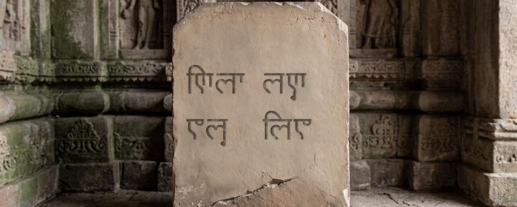

# 石板上的四個字

這是在喀什米爾一帶、源自西元 8 世紀、歷史上曾經用於書寫克什米爾語（Kashmiri）的**夏拉達文字**（Śāradā）。你沒學過它很正常，這正是重點！語奧解題不需要靠任何記憶，只靠觀察與推理。

石板上刻的，就是下面要解開的四個單字。

任務一

## 把文字配回讀音拼寫

石板上有四個詞，下面則是語言考古學家記下的四個讀音，但順序全亂了。先點選石板上的字，再點下面的讀音，就完成一組配對。

任務二

## 新出現的字母

任務三

## 把「kālu」刻出來

最後一道封印還沒刻上去。用下面的字母台，一個音節一個音節組出 kālu。先選子音，再選母音，字就會出現在石板上。

子音

母音

選一個子音，再選一個母音

重點

## 寫的順序，不等於唸的順序

母音 i 的符號寫在子音**左邊**，但唸的時候在子音**後面**。按一下切換，看它換到「唸的順序」。

寫的順序**目前：寫的順序**

**解答與推理路線**

**第一步：找出重複出現的整塊字形。**妳會發現只有一個形狀出現兩次：③ 的第一塊和 ④ 的第二塊。讀音裡，只有 jālu 的第一個音節和 lijā 的第二個音節相同（都是 jā）。所以 ③ = jālu、④ = lijā，沒有別的可能。

**第二步：拆出字母。**從 ③④ 可知那塊重複的字形 = jā。④ 的第一塊帶著一個左邊的像鐮刀的勾，而 ② 的第一塊沒有勾但骨架相同，所以可以推出勾是母音 i，骨架 是 l。剩下 ① 的第一塊骨架與 ③ 同源， 就是 j。

**第三步：三個母音符號各就各位。**寫在右邊的一豎 = ā；掛在字母底下的勾 = u；寫在左邊、卻唸在後面的勾 = i。沒有加任何符號的字母，自帶母音 a。這就是印度系文字的通則，② laju 的第一個音節就是證據。

| 石板 | 讀音 | 拆解 |
| --- | --- | --- |
|  | jilā（冰凍） | ji ＋ lā |
|  | laju（雷電） | la ＋ ju |
|  | jālu（火焰） | jā ＋ lu |
|  | lijā（暴風） | li ＋ jā |
|  | kilā | ki ＋ lā |
|  | kāju | kā ＋ ju |
|  | kālu | kā ＋ lu |

**字母表：三個子音、四個母音**

**加碼一題：勾跑到中間去了**

**這是真的文字嗎？**

**字母與拼寫規則是真的。**夏拉達文約在八世紀出現於喀什米爾，用來寫梵語與喀什米爾語，是天城文的近親、也是錫克教古木基文的祖先；它至今仍留在 Unicode 裡（U+11180–U+111DF）。母音 i 寫在左邊、u 掛在底下、不加符號自帶 a——這些都是它真實的規則。

**但是詞彙與「咒語」是編的。**為了讓題目乾淨好解，這裡的四個單字是特意造出來的音節組合，意思也是虛構的。要注意的是，真正的語奧題目絕大部分使用真實的語言材料。

**想學學這種酷酷的文字嗎？**

我做了一個互動網頁，[玩看看](https://loperntu.github.io/iol/sharada.html)。